# Transformando Dados em Segurança: Detecção de Fraudes em Pagamentos

Julho 2024

# 1. Descrição Geral do Problema

[figure not shown]

A fraude em transações financeiras representa um desafio significativo para instituições financeiras ao redor do mundo, causando prejuízos substanciais tanto para as instituições quanto para os clientes. O aumento das transações online e a sofisticação das técnicas fraudulentas tornam a detecção de fraudes uma tarefa cada vez mais complexa e crítica.

Neste contexto, o objetivo deste projeto é desenvolver um modelo preditivo capaz de identificar transações fraudulentas com alta precisão. A detecção eficaz de fraudes não só ajuda a minimizar as perdas financeiras, mas também a aumentar a segurança e a confiança dos clientes nos sistemas financeiros.

**Data Science Workflow Canvas**

| **Elemento** | **Descrição** |
| --- | --- |
| **Problema de Negócio** | A crescente incidência de fraudes financeiras online está causando perdas significativas para instituições financeiras e clientes. O projeto pretende identificar transações fraudulentas com alta preci… |
| **Outcomes/Prediction** | Identificar transações fraudulentas com alta precisão utilizando técnicas de aprendizado de máquina. |
| **Data Acquisition** | Conjunto de dados do Kaggle contendo informações sobre transações fraudulentas e não fraudulentas. |
| **Data Preparation** | Transformação de variáveis categóricas em numéricas, normalização e redução de dimensionalidade. |
| **Exploração de Dados** | Análise exploratória inicial para entender as características e distribuição das variáveis. |
| **Modeling** | Treinamento de modelo Gradient Boosting escolhido e ajustado para prever transações fraudulentas, ajuste de hiperparâmetros e uso de GridSearchCV para otimizar a performance do modelo. |
| **Model Evaluation** | Avaliação da performance do modelo usando precisão, recall, f1-score e matriz de confusão. |
| **Prediction** | Teste do modelo com transações de exemplo ajustadas para verificar a capacidade de detecção de fraudes. |
| **Conclusões e Recomendações** | Resultados obtidos e recomendações baseadas nas análises e modelagem. |

# 2. Carregar Bibliotecas de Interesse

```python
import pandas as pd  # Biblioteca para manipulação e análise de dados
import numpy as np   # Biblioteca para cálculos numéricos e operações com arrays

# Bibliotecas para visualização de dados
import matplotlib.pyplot as plt  # Biblioteca para criação de gráficos
import seaborn as sns            # Biblioteca para visualização de dados baseada no matplotlib

from sklearn.model_selection import GridSearchCV         # Ferramenta para otimização de hiperparâmetros com validação cruzada

from IPython.display import display, Markdown, HTML      # Ferramentas para exibição de dados no Jupyter Notebook

# Importação de modelos e métricas do scikit-learn
from sklearn.ensemble import GradientBoostingClassifier  # Modelo de classificação baseado em gradient boosting
from sklearn.metrics import accuracy_score, classification_report, confusion_matrix  # Ferramentas para avaliação de modelos

from imblearn.over_sampling import SMOTE  # Técnica para balanceamento de classes através de superamostragem

# Função para dividir os dados em conjuntos de treinamento e teste
from sklearn.model_selection import train_test_split     # Função para divisão de dados em treinamento e teste

# Ferramentas de pré-processamento de dados
from sklearn.preprocessing import StandardScaler         # Ferramenta para normalização de dados

# Ferramenta para redução de dimensionalidade
from sklearn.decomposition import PCA                    # Análise de Componentes Principais para redução de dimensionalidade

import warnings                                          # Biblioteca para gerenciamento de advertências
warnings.filterwarnings("ignore")                        # Supressão global de advertências para limpar a saída do notebook
```

# 3. Função de Uso em Gráficos

```python
# Função para aplicar estilo aos gráficos

def estilo_grafico():

    sns.set_style('whitegrid')

    plt.rcParams.update({

        'axes.spines.top': False,         # Remover a borda superior

        'axes.spines.right': False,       # Remover a borda direita

        'axes.spines.left': False,        # Remover a borda esquerda

        'axes.spines.bottom': True,       # Manter a borda inferior

        'axes.edgecolor': 'black',        # Cor da borda dos eixos

        'axes.facecolor': 'white',        # Cor de fundo dos eixos

        'grid.color': 'gray',             # Cor da grade

        'grid.linestyle': '--',           # Estilo da linha da grade

        'grid.alpha': 0.7,                # Transparência da grade

        'grid.linewidth': 0.7,            # Largura da linha da grade

        'figure.facecolor': 'white',      # Cor de fundo da figura

        'savefig.facecolor': 'white',     # Cor de fundo ao salvar a figura

    })

    # Define a paleta de cores
    cores_personalizadas = ['#184E77', '#1e6091', '#1a759f', '#168aad', '#34a0a4', '#52b69a', '#76c893', '#99d98c', '#b5e48c', '#d9ed92']
    sns.set_palette(cores_personalizadas)
```

### 3.1 Função para Formatar Valor

```python
# Função para formatar os valores em moeda americana sem símbolo
def formatar_valor(valor):
    return f'{valor:,.2f}'
```

# 4. Exploração Inicial dos Dados

### 4.1. Carrega os Dados e Exibi os Primeiros Registros

```python
#********** carregar conjunto de dados ************
dados = pd.read_csv(r'data\data_fraud.csv')

#********* apresenta primeiros registros ***********
dados.head()
```

|  | step | type | amount | nameOrig | oldbalanceOrg | newbalanceOrig | nameDest | oldbalanceDest | newbalanceDest | isFraud | isFlaggedFraud |
| --- | --- | --- | --- | --- | --- | --- | --- | --- | --- | --- | --- |
| 0 | 1 | PAYMENT | 9839.64 | C1231006815 | 170136.00 | 160296.36 | M1979787155 | 0.00 | 0.00 | 0 | 0 |
| 1 | 1 | PAYMENT | 1864.28 | C1666544295 | 21249.00 | 19384.72 | M2044282225 | 0.00 | 0.00 | 0 | 0 |
| 2 | 1 | TRANSFER | 181.00 | C1305486145 | 181.00 | 0.00 | C553264065 | 0.00 | 0.00 | 1 | 0 |
| 3 | 1 | CASH_OUT | 181.00 | C840083671 | 181.00 | 0.00 | C38997010 | 21182.00 | 0.00 | 1 | 0 |
| 4 | 1 | PAYMENT | 11668.14 | C2048537720 | 41554.00 | 29885.86 | M1230701703 | 0.00 | 0.00 | 0 | 0 |

## 4.2 Apresenta Metadados de Cada Variável

| Variável | Descrição | Tipo de Dados |
| --- | --- | --- |
| `step` | Passo da transação (representa um instante no tempo) | int64 |
| `type` | Tipo de transação (ex: PAYMENT, TRANSFER, CASH_OUT) | object |
| `amount` | Valor da transação | float64 |
| `nameOrig` | Identificação do cliente que originou a transação | object |
| `oldbalanceOrg` | Saldo antigo do cliente que originou a transação | float64 |
| `newbalanceOrig` | Novo saldo do cliente que originou a transação | float64 |
| `nameDest` | Identificação do cliente que recebeu a transação | object |
| `oldbalanceDest` | Saldo antigo do cliente que recebeu a transação | float64 |
| `newbalanceDest` | Novo saldo do cliente que recebeu a transação | float64 |
| `isFraud` | Indica se a transação é fraudulenta (1 para sim, 0 para não) | int64 |
| `isFlaggedFraud` | Indica se a transação foi sinalizada como potencialmente fraudulenta pelo sistema (1/0) | int64 |

## 4.3 Análise de Dados Faltantes

```python
# *********** Calcula o total e a porcentagem de dados faltantes por coluna ***********

total_faltantes = dados.isnull().sum()

percentual_faltantes = (dados.isnull().mean() * 100)

#********* cria dataframe para tabela resumida *********

tabela_resumo_faltantes = pd.DataFrame({'Coluna': total_faltantes.index,

                                     'Dados faltantes': total_faltantes.values,

                                     'Percentual (%)': percentual_faltantes.values
                                    })

#*************** Ordenar tabela pelo numero de faltantes *****************

tabela_resumo_faltantes = tabela_resumo_faltantes.sort_values(by='Dados faltantes', ascending=False)

#************ Exibe tabela resumida *************

display(Markdown("<h3 style='color: darkred'> Tabela Resumo de Dados Faltantes</h3>"))

print(tabela_resumo_faltantes)
print()
```

Tabela Resumo de Dados Faltantes

```
            Coluna  Dados faltantes  Percentual (%)
0             step                0            0.00
1             type                0            0.00
2           amount                0            0.00
3         nameOrig                0            0.00
4    oldbalanceOrg                0            0.00
5   newbalanceOrig                0            0.00
6         nameDest                0            0.00
7   oldbalanceDest                0            0.00
8   newbalanceDest                0            0.00
9          isFraud                0            0.00
10  isFlaggedFraud                0            0.00
```

# 4.4. Análise de Dados Duplicados

```python
nume_duplicados = dados.duplicated().sum()

#********** Calcula o percentual de duplicados com o total de registros *************

percentual_duplicados = ((nume_duplicados / len(dados) * 100))

#********* verifica existencia de duplicado *********

if percentual_duplicados > 0: # se existe duplicados

     display(Markdown(f"<h3 style='color: darkred'>Foram encontrados {numero_duplicados} registros duplicados, representando {percentual_duplicados:.2f}% do total de {dados.shape[0]} registros!</h3>"))

else:

    display(Markdown("<h2 style='color: red'>Não foram encontrados dados duplicados no conjunto de dados</h2>"))

print()
```

Não foram encontrados dados duplicados no conjunto de dados

# 4.5 Resumo Estatístico das Variáveis Numéricas

```python
#********** Configurando a formatação de números flutuantes para duas casas decimais *********

pd.options.display.float_format = '{:.2f}'.format


# ********* Gerando o resumo estatístico dos dados ***********

estatisticas = dados.describe()


# *********** Renomeando as colunas e índices do resumo estatístico para português ***********

estatisticas.rename(columns={

    'count': 'contagem',

    'mean': 'média',

    'std': 'desvio_padrão',

    'min': 'mínimo',

    '25%': '1º quartil 25%',

    '50%': 'mediana 50%',

    '75%': '3º quartil 75%',

    'max': 'máximo'

}, index={

    'count': 'contagem',

    'mean': 'média',

    'std': 'desvio_padrão',

    'min': 'mínimo',

    '25%': '1º quartil 25%',

    '50%': 'mediana 50%',

    '75%': '3º quartil 75%',

    'max': 'máximo'

}, inplace=True)

#*********** Imprimindo o resumo estatístico formatado e traduzido ***********

print(estatisticas)
```

```
                     step      amount  oldbalanceOrg  newbalanceOrig  \
contagem       6362620.00  6362620.00     6362620.00      6362620.00
média              243.40   179861.90      833883.10       855113.67
desvio_padrão      142.33   603858.23     2888242.67      2924048.50
mínimo               1.00        0.00           0.00            0.00
1º quartil 25%     156.00    13389.57           0.00            0.00
mediana 50%        239.00    74871.94       14208.00            0.00
3º quartil 75%     335.00   208721.48      107315.18       144258.41
máximo             743.00 92445516.64    59585040.37     49585040.37

                oldbalanceDest  newbalanceDest    isFraud  isFlaggedFraud
contagem            6362620.00      6362620.00 6362620.00      6362620.00
média               1100701.67      1224996.40       0.00            0.00
desvio_padrão       3399180.11      3674128.94       0.04            0.00
mínimo                    0.00            0.00       0.00            0.00
1º quartil 25%            0.00            0.00       0.00            0.00
mediana 50%          132705.66       214661.44       0.00            0.00
3º quartil 75%       943036.71      1111909.25       0.00            0.00
máximo            356015889.35    356179278.92       1.00            1.00
```

# 4.6 Verificação do Número de Observações e Colunas

```python
# Formatação dos números para milhões

num_observacoes = f"{dados.shape[0]:,}".replace(',', '.')

num_colunas = f"{dados.shape[1]:,}".replace(',', '.')

# Apresentação em Markdown

display(Markdown(f"<h3 style='color: darkblue'>Verificamos a existência de {num_observacoes} observações e {num_colunas} colunas no DataSet.</h3>"))
```

[output not shown]

## 4.7 Contabilizando o número de valores únicos em cada variável do dataset.¶

```python
# *******************Contabilizando o número de valores únicos em cada variável do dataset *******************

num_valor_unico = dados.nunique().sort_values()

# Determinando o tipo de dado de cada uma das variáveis do dataset.

num_valor_unico = pd.DataFrame(num_valor_unico.values, index = num_valor_unico.index, columns = ['valor_unicos'])

# Atribuindo informações sobre o tipo de dado das variáveis ao DataFrame.

num_valor_unico
```

|  | valor_unicos |
| --- | --- |
| isFraud | 2 |
| isFlaggedFraud | 2 |
| type | 5 |
| step | 743 |
| oldbalanceOrg | 1845844 |
| newbalanceOrig | 2682586 |
| nameDest | 2722362 |
| newbalanceDest | 3555499 |
| oldbalanceDest | 3614697 |
| amount | 5316900 |
| nameOrig | 6353307 |

## 4.8. Análise dos Tipos de Transações

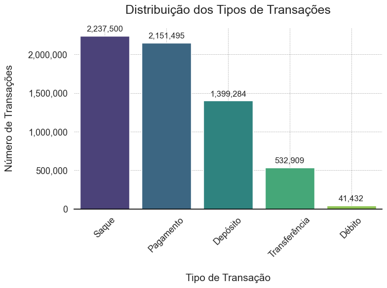

```python
# Aplicando o estilo personalizado aos gráficos
estilo_grafico()

# Definindo um dicionário para mapear os tipos de transação para descrições
tipos_transacao = {

    "PAYMENT": "Pagamento",

    "TRANSFER": "Transferência",

    "CASH_OUT": "Saque",

    "DEBIT": "Débito",

    "CASH_IN": "Depósito"
}

# Mapeando os valores numéricos da coluna 'type' para suas descrições correspondentes
dados['type_desc'] = dados['type'].map(tipos_transacao)

# Contando a quantidade de cada tipo de transação
tipos = dados['type_desc'].value_counts()

# Ajustando o tamanho da figura para 8x6 polegadas
plt.figure(figsize=(8, 6))

# Criando o gráfico de barras para visualizar a distribuição dos tipos de transações
ax = sns.barplot(x=tipos.index, y=tipos.values, palette="viridis")

# Configurando o título do gráfico com espaçamento ajustado
plt.title('Distribuição dos Tipos de Transações', fontsize=18, pad=20)

# Configurando o rótulo do eixo x
plt.xlabel('Tipo de Transação', fontsize=15, labelpad=20)

# Configurando o rótulo do eixo y
plt.ylabel('Número de Transações', fontsize=15, labelpad=20)

# Ajustando a rotação e o tamanho da fonte das etiquetas do eixo x
plt.xticks(rotation=45, fontsize=13)

# Ajustando o tamanho da fonte das etiquetas do eixo y
plt.yticks(fontsize=13)

# Formatando o eixo y para evitar notação científica usando FuncFormatter
ax.yaxis.set_major_formatter(ticker.FuncFormatter(lambda x, pos: '{:,.0f}'.format(x)))

# Colocando a grade atrás das barras
ax.set_axisbelow(True)
plt.grid(True, which='both', linestyle='--', linewidth=0.5)

# Centralizando o gráfico na figura
plt.tight_layout()


# Adicionando anotações acima de cada barra com o número formatado
for p in ax.patches:

    ax.annotate(format(p.get_height(), ',.0f'),

                (p.get_x() + p.get_width() / 2., p.get_height()),

                ha='center', va='center', xytext=(0, 10),

                textcoords='offset points', fontsize=12)

# Exibindo o gráfico
plt.show()
```

### Análise

| **Tipo de Transação** | **Observação** |
| --- | --- |
| **Saque** | Mais comum (2.237.500 transações), indicando alta preferência por retiradas de dinheiro. |
| **Pagamento** | Segunda mais frequente (2.151.495 transações), sugerindo uso significativo para contas ou compras. |
| **Depósito** | Terceira em frequência (1.399.284 transações), mostrando atividade constante de adição de fundos. |
| **Transferência** | Significativa (532.909 transações), possivelmente entre contas ou bancos diferentes. |
| **Débito** | Menos comum (41.432 transações), indicando menor uso ou registro. |

# 5. Definição e Transformação das Variáveis Categóricas e Numéricas

```python
#*********** Definindo as variáveis numéricas e categóricas *********
variaveis_numericas = [

    'step', 'amount', 'oldbalanceOrg', 'newbalanceOrig',

    'oldbalanceDest', 'newbalanceDest', 'isFraud', 'isFlaggedFraud'
]

variaveis_categoricas = ['type', 'nameOrig', 'nameDest']


# Garantindo que todas as variáveis numéricas estejam no formato correto

dados[variaveis_numericas] = dados[variaveis_numericas].apply(pd.to_numeric, errors='coerce')


# Transformando a variável categórica "type" em numérica automaticamente

dados['type'] = dados['type'].astype('category').cat.codes
```

# 5.1 Verificação e Validação de Codificação de Variáveis Categóricas

```python
# Verificando a correta transformação das variáveis categóricas em códigos numéricos
print("Verificação dos códigos únicos para variáveis transformadas:")

for var in variaveis_categoricas:

    print(f"{var}: {dados[var].unique()}")
```

```
Verificação dos códigos únicos para variáveis transformadas:
type: [3 4 1 2 0]
nameOrig: ['C1231006815' 'C1666544295' 'C1305486145' ... 'C1162922333' 'C1685995037'
 'C1280323807']
nameDest: ['M1979787155' 'M2044282225' 'C553264065' ... 'C1850423904' 'C1881841831'
 'C2080388513']
```

# 5.2 Scatter Plots com Segmentação

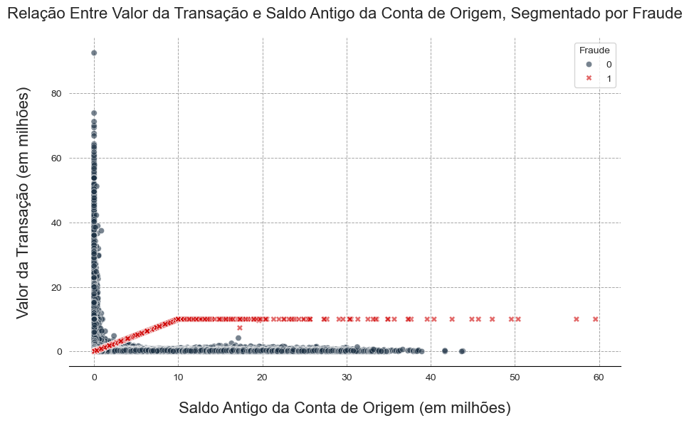

```python
estilo_grafico()

# Convertendo valores para milhões

dados['oldbalanceOrg_milhoes'] = dados['oldbalanceOrg'] / 1e6

dados['amount_milhoes'] = dados['amount'] / 1e6

# definindo tamanho do gráfico
plt.figure(figsize=(10, 6))

sns.scatterplot(x='oldbalanceOrg_milhoes', y='amount_milhoes', hue='isFraud', data=dados, style='isFraud', palette=['#1C3144','#D00000'], markers={0:'o', 1:'X'}, alpha=0.6)

plt.title('Relação Entre Valor da Transação e Saldo Antigo da Conta de Origem, Segmentado por Fraude', fontsize=16, pad=20)

plt.xlabel('Saldo Antigo da Conta de Origem (em milhões)', fontsize=15, labelpad=20)

plt.ylabel('Valor da Transação (em milhões)', fontsize=15, labelpad=20)

plt.legend(title='Fraude')

plt.show()
```

O gráfico apresenta a relação entre o valor da transação e o saldo antigo da conta de origem, segmentado por transações fraudulentas e não fraudulentas.

## Insight Geral

A análise do gráfico indica que há uma clara distinção entre os padrões de transações fraudulentas e não fraudulentas. Enquanto as transações não fraudulentas mostram uma ampla variação em relação ao saldo antigo da conta de origem, as transações fraudulentas tendem a ocorrer dentro de uma faixa mais limitada de saldo e valor.

# 5.3 Time Series Analysis

## Visualizar a contagem de transações fraudulentas ao longo do tempo, usando a variável step como referência temporal.

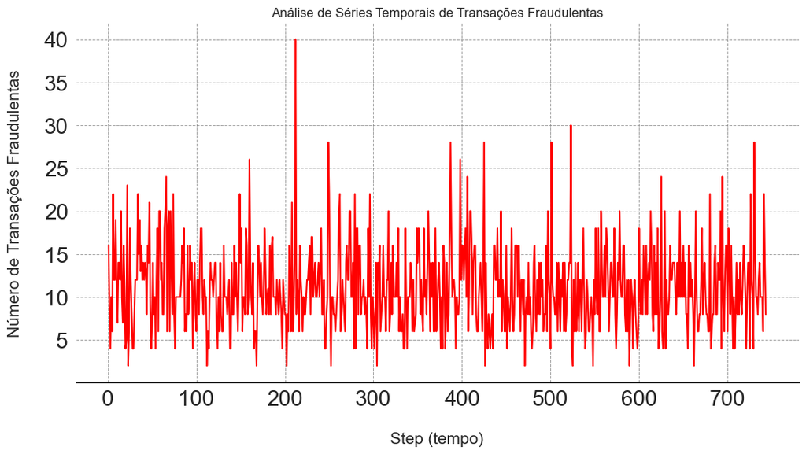

```python
estilo_grafico()

# Agrupando dados por 'step' e contando transações fraudulentas
fraud_over_time = dados[dados['isFraud'] == 1].groupby('step').size()

plt.figure(figsize=(12, 6))

fraud_over_time.plot(title='Análise de Séries Temporais de Transações Fraudulentas', color='red', fontsize=20)  # Título do gráfico

plt.xlabel('Step (tempo)', fontsize=15, labelpad=20)  # Rótulo do eixo X

plt.ylabel('Número de Transações Fraudulentas', fontsize=15, labelpad=20)  # Rótulo do eixo Y

plt.grid(True)

plt.show() # Exibe o gráfico
```

### Análise

[output not shown]

# 6. Correlação Entre as Variáveis

```python
# Listando as variáveis numéricas e categóricas
variaveis_numericas = ['step', 'amount', 'oldbalanceOrg', 'newbalanceOrig',

                       'oldbalanceDest', 'newbalanceDest', 'isFraud', 'isFlaggedFraud']

variaveis_categoricas = ['type', 'nameOrig', 'nameDest']


# Convertendo variáveis categóricas em códigos numéricos
for var in variaveis_categoricas:                                   # O loop vai percorrer cada variável categórica na lista variaveis_categoricas
    dados[var] = dados[var].astype('category').cat.codes            # Vai acessar a coluna correspondente à variável categórica atual no dataframe dados


# Vamos garantir aqui que todas as variáveis numéricas estejam no formato correto
dados[variaveis_numericas] = dados[variaveis_numericas].apply(pd.to_numeric, errors='coerce')


# Preparando os dados removendo as colunas que ainda possam conter valores não numéricos
dados_limpos = dados.drop(columns=[col for col in dados.columns if col not in variaveis_numericas + variaveis_categoricas])


# Calculando a correlação entre as variáveis numéricas
correlacao = dados_limpos.corr()


# Exibindo a correlação da variável 'isFraud' com as demais variáveis, em ordem decrescente
correlacao_isFraud = correlacao["isFraud"].sort_values(ascending=False)
print(correlacao_isFraud)


# Identificando a variável mais fortemente correlacionada com 'isFraud', excluindo 'isFraud' ela mesma
variavel_mais_forte = correlacao_isFraud.index[1]


print(f"\nVariável mais fortemente correlacionada com 'isFraud': {variavel_mais_forte}")
```

```
isFraud           1.00
amount            0.08
isFlaggedFraud    0.04
step              0.03
type              0.02
oldbalanceOrg     0.01
newbalanceDest    0.00
nameOrig         -0.00
oldbalanceDest   -0.01
newbalanceOrig   -0.01
nameDest         -0.02
Name: isFraud, dtype: float64

Variável mais fortemente correlacionada com 'isFraud': amount
```

### 6.1 Gráfico de dispersão para visualizar a relação entre 'isFraud' e a variável mais fortemente correlacionada

Gráfico de dispersão para mostra a relação entre o valor da transação e a indicação de fraude (isFraud).

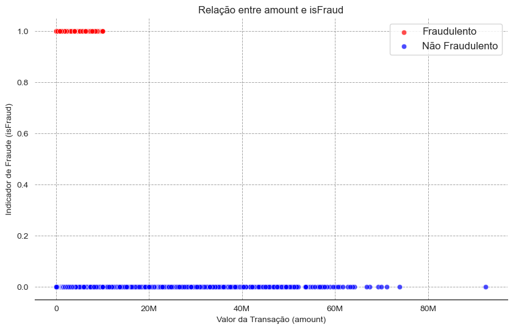

```python
# Definindo o estilo do gráfico
estilo_grafico()

plt.figure(figsize=(10, 6))

# Plotando os pontos de dados para transações fraudulentas e não fraudulentas
sns.scatterplot(data=dados[dados['isFraud'] == 1], x='amount', y='isFraud', color='red', alpha=0.7, label='Fraudulento')
sns.scatterplot(data=dados[dados['isFraud'] == 0], x='amount', y='isFraud', color='blue', alpha=0.7, label='Não Fraudulento')

# Ajustando os rótulos do eixo X
plt.xticks(ticks=[0, 2e7, 4e7, 6e7, 8e7], labels=['0', '20M', '40M', '60M', '80M'])

# Títulos e rótulos
plt.title('Relação entre amount e isFraud')
plt.xlabel('Valor da Transação (amount)')
plt.ylabel('Indicador de Fraude (isFraud)')

# Adicionando a legenda no canto superior esquerdo
plt.legend(loc='upper right', fontsize=12)

plt.show()
```

### 6.2 Heatmap de Correlação entre as Variáveis

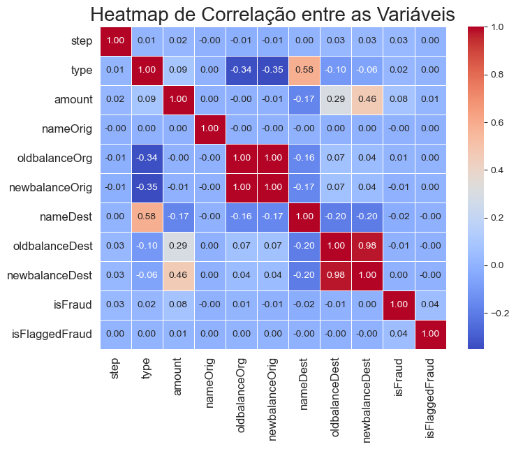

```python
# Criando o heatmap de correlação com fonte legível para web e celular

plt.figure(figsize=(8, 6))

sns.heatmap(correlacao, annot=True, cmap='coolwarm', fmt='.2f', linewidths=.5)

plt.title('Heatmap de Correlação entre as Variáveis', fontsize=20, fontname='Arial')

plt.xticks(fontsize=12, fontname='Arial')

plt.yticks(fontsize=12, fontname='Arial')

plt.show()
```

### Análise

- A correlação entre `newbalanceDest` e `oldbalanceDest` é alta (0.98), indicando que o saldo antigo do destino está fortemente relacionado ao novo saldo do destino.
- As correlações entre `isFraud` e outras variáveis são baixas, com a maior sendo 0.08 com amount. Isso indica que nenhuma variável individual tem uma forte relação com a fraude.

### 6.4 Violin Plot com Escala Logarítmica

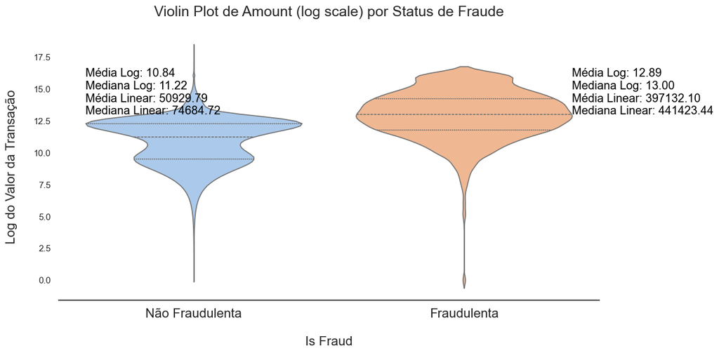

```python
# Aplicando transformação logarítmica aos valores das transações
dados['log_amount'] = np.log1p(dados['amount'])

# Criando o gráfico de violino
plt.figure(figsize=(12, 6))
sns.set(style="white")
plt.rcParams.update({

        'axes.spines.top': False,

        'axes.spines.right': False,

        'axes.spines.left': False,

        'axes.spines.bottom': True,
})

ax = sns.violinplot(x='isFraud', y='log_amount', data=dados, inner='quartile', palette='pastel')

# Adicionando anotações de média e mediana
for i in range(2):
    group_data = dados[dados['isFraud'] == i]['log_amount']
    mean_log = group_data.mean()
    median_log = group_data.median()
    mean_linear = np.expm1(mean_log)
    median_linear = np.expm1(median_log)

    if i == 0:
        x_pos = -0.4
    else:
        x_pos = 1.4

    plt.text(x_pos, 16, f'Média Log: {mean_log:.2f}', horizontalalignment='left', size='large', color='black')
    plt.text(x_pos, 15, f'Mediana Log: {median_log:.2f}', horizontalalignment='left', size='large', color='black')
    plt.text(x_pos, 14, f'Média Linear: {mean_linear:.2f}', horizontalalignment='left', size='large', color='black')
    plt.text(x_pos, 13, f'Mediana Linear: {median_linear:.2f}', horizontalalignment='left', size='large', color='black')

# Configurações do gráfico
plt.title('Violin Plot de Amount (log scale) por Status de Fraude', fontsize=18, pad=20)
plt.xlabel('Is Fraud', labelpad=20, fontsize=16)
plt.ylabel('Log do Valor da Transação', labelpad=20,  fontsize=16)

# Ajustar rótulos do eixo x
ax.set_xticklabels(['Não Fraudulenta', 'Fraudulenta'], fontsize=16)

# Remover linhas de grade
plt.grid(False)

plt.show()
```

A escala logarítmica no gráfico de violino é útil para visualizar distribuições em dados com grande variação, e para uma análise mais precisa é importante considerar tanto a visualização logarítmica quanto os valores reais dos dados.

## 6.4. Histograma da Distribuição dos Valores das Transações

Visualiza a distribuição dos valores das transações no conjunto de dados.

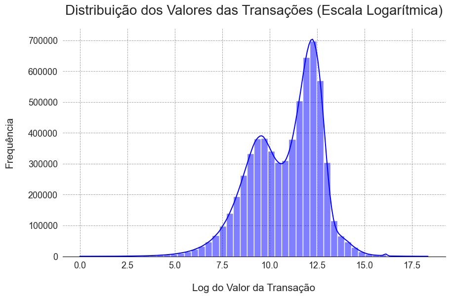

```python
estilo_grafico()

# Aplicando transformação logarítmica aos valores das transações para melhorar a visualização
dados['log_amount'] = np.log1p(dados['amount'])  # np.log1p aplica log(1 + valor), importante para lidar com valores zero

plt.figure(figsize=(10, 6))

sns.histplot(dados['log_amount'], bins=50, kde=True, color='blue')  # Cria o histograma dos valores transformados

plt.title('Distribuição dos Valores das Transações (Escala Logarítmica)', fontsize=18, pad=20)  # Título do gráfico

plt.xlabel('Log do Valor da Transação', fontsize=15, labelpad=20)  # Rótulo do eixo X

plt.ylabel('Frequência', fontsize=15, labelpad=20)  # Rótulo do eixo Y

plt.xticks(fontsize=13)  # Tamanho da fonte dos rótulos do eixo X

plt.yticks(fontsize=13)  # Tamanho da fonte dos rótulos do eixo Y

plt.show()  # Exibe o gráfico
```

A maior frequência de transações ocorre em torno do logaritmo do valor 12.5. Isso sugere que a maioria das transações está concentrada em valores que, quando transformados de volta para a escala linear, representam uma quantidade significativa de dinheiro.

# 6.5. Box Plot da Distribuição dos Valores das Transações por Fraude

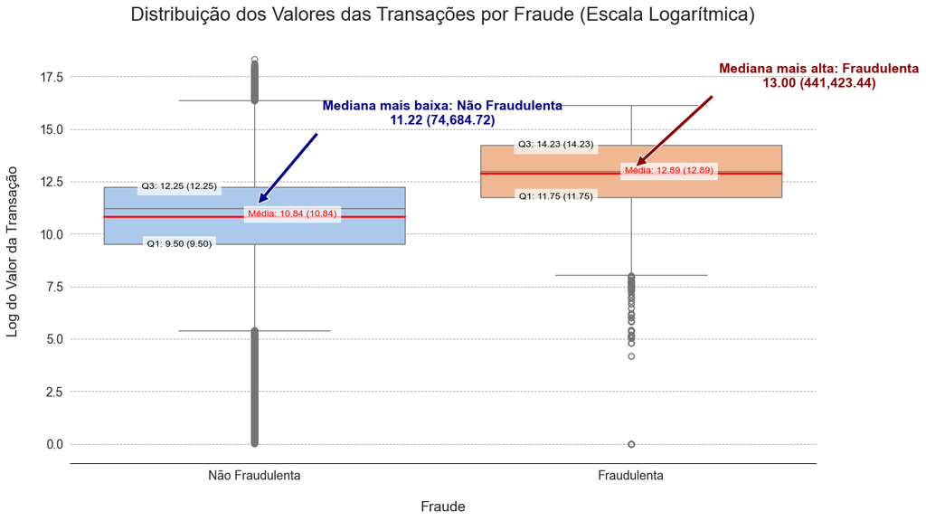

```python
estilo_grafico()

# Aplicando transformação logarítmica aos valores das transações
dados['log_amount'] = np.log1p(dados['amount'])

# Calculando estatísticas descritivas
stats = dados.groupby('isFraud')['log_amount'].describe()


# Variáveis de controle para informações na caixa

deslocamento_media = - 0.1

deslocamento_variancia = 1.0

deslocamento_anotacao_medianas = 4.0

altura_anotacao_medianas = 2


# Configurações do gráfico

plt.figure(figsize=(14, 8))

ax = sns.boxplot(x='isFraud', y='log_amount', data=dados, palette='pastel')



# Adicionar linhas de média e anotações para quartis e variância

for i, fraud_status in enumerate(dados['isFraud'].unique()):

    mean_value = stats.loc[fraud_status, 'mean']

    q1 = stats.loc[fraud_status, '25%']

    median = stats.loc[fraud_status, '50%']

    q3 = stats.loc[fraud_status, '75%']

    variance_log = np.var(dados[dados['isFraud'] == fraud_status]['log_amount'])

    variance_real = np.var(dados[dados['isFraud'] == fraud_status]['amount'])


    # Anotação para média

    plt.plot([i - 0.4, i + 0.4], [mean_value, mean_value], color='red', lw=2)

    plt.text(i + 0.1, mean_value + deslocamento_media, f'Média: {mean_value:.2f} ({formatar_valor(mean_value)})', ha='center', va='bottom', fontsize=10, color='red', bbox=dict(facecolor='white', alpha=0.7))

    # Anotações para quartis

    plt.text(i - 0.2, q1, f'Q1: {q1:.2f} ({formatar_valor(q1)})', ha='center', va='center', fontsize=10, color='black', bbox=dict(facecolor='white', alpha=0.7))

    plt.text(i - 0.2, q3, f'Q3: {q3:.2f} ({formatar_valor(q3)})', ha='center', va='center', fontsize=10, color='black', bbox=dict(facecolor='white', alpha=0.7))


# Adicionando anotação para a maior e menor mediana

median_values = stats['50%']

highest_median_fraud = median_values.idxmax()

lowest_median_fraud = median_values.idxmin()

highest_median_value = median_values.max()

lowest_median_value = median_values.min()


plt.annotate(f'Mediana mais alta: {"Fraudulenta" if highest_median_fraud else "Não Fraudulenta"}\n{highest_median_value:.2f} ({formatar_valor(valor_real(highest_median_value))})',

             xy=(highest_median_fraud, highest_median_value),

             xytext=(highest_median_fraud + 0.5, highest_median_value + deslocamento_anotacao_medianas),

             fontsize=14, color='darkred', ha='center', fontweight='bold',

             arrowprops=dict(facecolor='darkred', shrink=0.05))


plt.annotate(f'Mediana mais baixa: {"Fraudulenta" if lowest_median_fraud else "Não Fraudulenta"}\n{lowest_median_value:.2f} ({formatar_valor(valor_real(lowest_median_value))})',

             xy=(lowest_median_fraud, lowest_median_value),

             xytext=(lowest_median_fraud + 0.5, lowest_median_value + deslocamento_anotacao_medianas),

             fontsize=14, color='darkblue', ha='center', fontweight='bold',

             arrowprops=dict(facecolor='darkblue', shrink=0.05))


# Títulos e Rótulos

plt.title('Distribuição dos Valores das Transações por Fraude (Escala Logarítmica)', fontsize=18, pad=20)

plt.xlabel('Fraude', fontsize=15, labelpad=20)

plt.ylabel('Log do Valor da Transação', fontsize=15, labelpad=20)

plt.xticks(ticks=[0, 1], labels=['Não Fraudulenta', 'Fraudulenta'], fontsize=13)

plt.yticks(fontsize=15)

plt.show()
```

# 7. Divisão dos Dados em Conjuntos de Treinamento e Teste

```python
# Selecionando as características (features) para o modelo
# Convertendo as colunas "type", "amount", "oldbalanceOrg" e "newbalanceOrig" em um array NumPy
X = np.array(dados[["type", "amount", "oldbalanceOrg", "newbalanceOrig"]])

# Selecionando a variável alvo (target) "isFraud" para prever se a transação é fraudulenta
y = np.array(dados["isFraud"])


# Definindo test_size=0.2 (20%) dos dados serão usados para teste e 80% para treinamento
X_treino, X_teste, y_treino, y_teste = train_test_split(X, y, test_size=0.2, random_state=42)
```

# 7.1 Amostragem Estratificada

```python
# Definindo o tamanho da amostra
tamanho_amostra = 0.1  # 10% dos dados

# Amostragem estratificada

X = dados[["type", "amount", "oldbalanceOrg", "newbalanceOrig"]]

y = dados["isFraud"]

X_amostra, _, y_amostra, _ = train_test_split(X, y, train_size=tamanho_amostra, stratify=y, random_state=42)

display(Markdown(f"<h3 style='color: darkblue'>Tamanho da amostra: {X_amostra.shape[0]} registros.</h3>"))
```

Tamanho da amostra: 636262 registros.